# ML practice 9: Clustering

В прошлый раз мы говорили про снижение размерности. Снижение размерности – это один из примеров обучения без учителя. Мы примерно представляем, чего мы хотим добиться, но у нас нет правильного ответа. Сегодня мы поговорим о другой задаче обучения без учителя, а именно о кластеризации.

Но прежде чем мы начнем, ответьте на пару вопросов:

- В чем состоит задача кластеризации?
- Для чего применяется кластеризация?

### Данные (Аресты)

Загружаем данные

```r
Arrests <-USArrests
```

Посмотрим на них

```r
str(Arrests)
```

```
## 'data.frame':    50 obs. of  4 variables:
##  $ Murder  : num  13.2 10 8.1 8.8 9 7.9 3.3 5.9 15.4 17.4 ...
##  $ Assault : int  236 263 294 190 276 204 110 238 335 211 ...
##  $ UrbanPop: int  58 48 80 50 91 78 77 72 80 60 ...
##  $ Rape    : num  21.2 44.5 31 19.5 40.6 38.7 11.1 15.8 31.9 25.8 ...
```

*Murder*, *Assault*, *Rape* – это количество арестов по соответствующим статьям на 100000 жителей. *UrbanPop* – доля городского населения в штате.

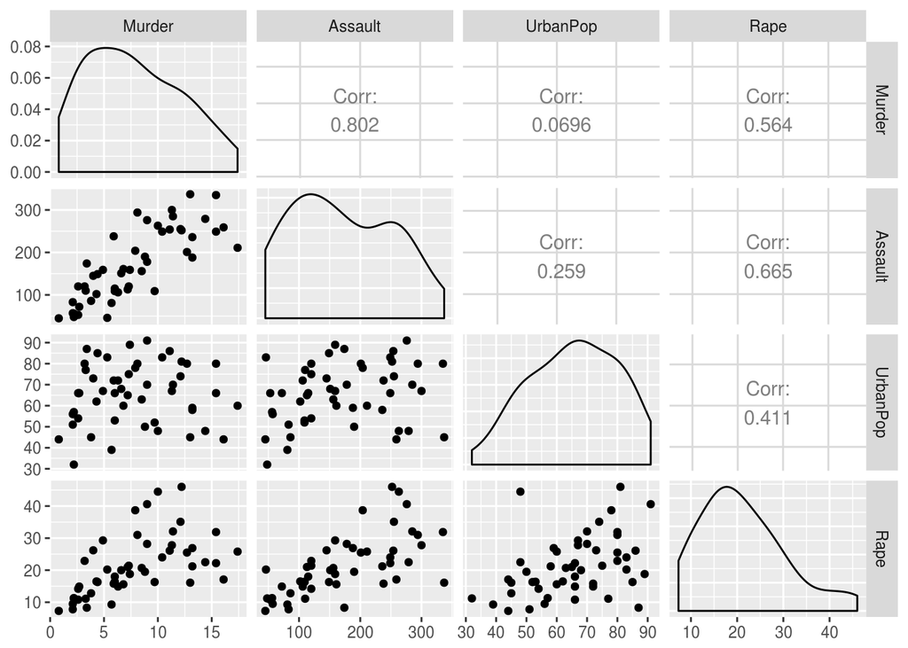

```r
library(ggplot2)
library(GGally)
ggpairs(Arrests)
```

Мы видим какие-то закономерности, например сильную коррелированность Murder и Assault.

Еще одно интересное наблюдение – бимодальность Assault, и было бы интересно понять, почему так происходит, но это не наша сегодняшняя задача.

Попробуем разделить штаты по похожести.

### Алгоритм k-means

Идея алгоритма очень проста:

1. Возьмем случайным образом k точек и назовем их центрами кластеров.
2. Для каждой точки найдем ближайший центр и будем считать, что точка пренадлежит этому кластеру.
3. Вычислим новые знацения центров, как среднее арифметическое координат точек приписанных этому кластеру на предыдущем шаге.
4. Будем повторять шаги 2-3 пока центры не перестанут менятся.

Начнем с двух кластеров:

```r
km.out=kmeans(Arrests,2,nstart=20)
km.out$cluster
```

```
##        Alabama         Alaska        Arizona       Arkansas     California
##              2              2              2              2              2
##       Colorado    Connecticut       Delaware        Florida        Georgia
##              2              1              2              2              2
##         Hawaii          Idaho       Illinois        Indiana           Iowa
##              1              1              2              1              1
##         Kansas       Kentucky      Louisiana          Maine       Maryland
##              1              1              2              1              2
##  Massachusetts       Michigan      Minnesota    Mississippi       Missouri
##              1              2              1              2              1
##        Montana       Nebraska         Nevada  New Hampshire     New Jersey
##              1              1              2              1              1
##     New Mexico       New York North Carolina   North Dakota           Ohio
##              2              2              2              1              1
##       Oklahoma         Oregon   Pennsylvania   Rhode Island South Carolina
##              1              1              1              1              2
##   South Dakota      Tennessee          Texas           Utah        Vermont
##              1              2              2              1              1
##       Virginia     Washington  West Virginia      Wisconsin        Wyoming
##              1              1              1              1              1
```

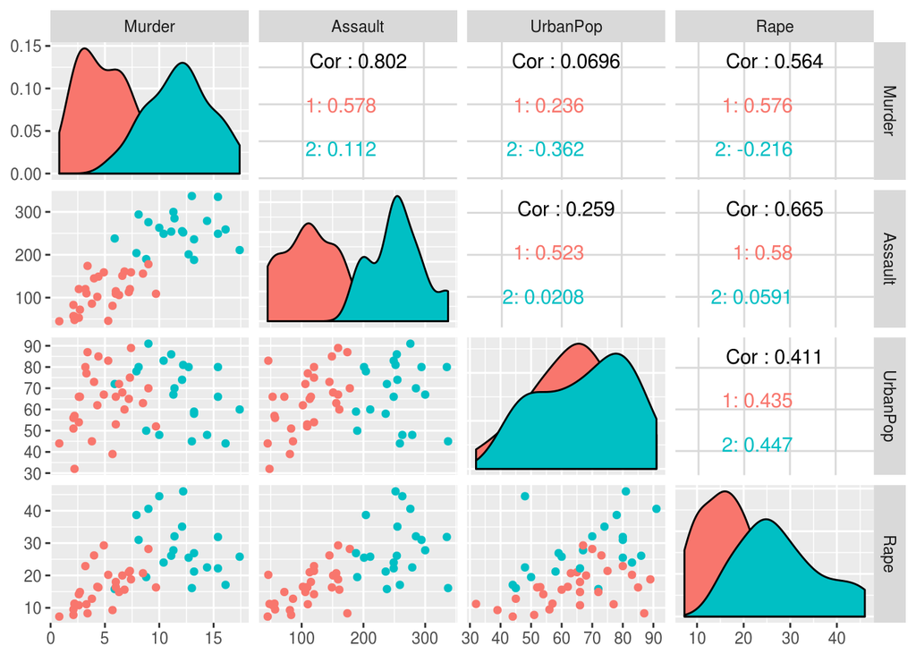

```r
Arrests$clusters = factor(km.out$cluster)
ggpairs(Arrests, mapping = ggplot2::aes(color = clusters), columns = c("Murder", "Assault", "UrbanPop", "Rape"))
```

А теперь 3 кластера:

```r
km.out=kmeans(Arrests,3,nstart=1)
km.out$cluster
```

```
##        Alabama         Alaska        Arizona       Arkansas     California
##              3              3              3              2              3
##       Colorado    Connecticut       Delaware        Florida        Georgia
##              2              1              3              3              2
##         Hawaii          Idaho       Illinois        Indiana           Iowa
##              1              1              3              1              1
##         Kansas       Kentucky      Louisiana          Maine       Maryland
##              1              1              3              1              3
##  Massachusetts       Michigan      Minnesota    Mississippi       Missouri
##              2              3              1              3              2
##        Montana       Nebraska         Nevada  New Hampshire     New Jersey
##              1              1              3              1              2
##     New Mexico       New York North Carolina   North Dakota           Ohio
##              3              3              3              1              1
##       Oklahoma         Oregon   Pennsylvania   Rhode Island South Carolina
##              2              2              1              2              3
##   South Dakota      Tennessee          Texas           Utah        Vermont
##              1              2              2              1              1
##       Virginia     Washington  West Virginia      Wisconsin        Wyoming
##              2              2              1              1              2
```

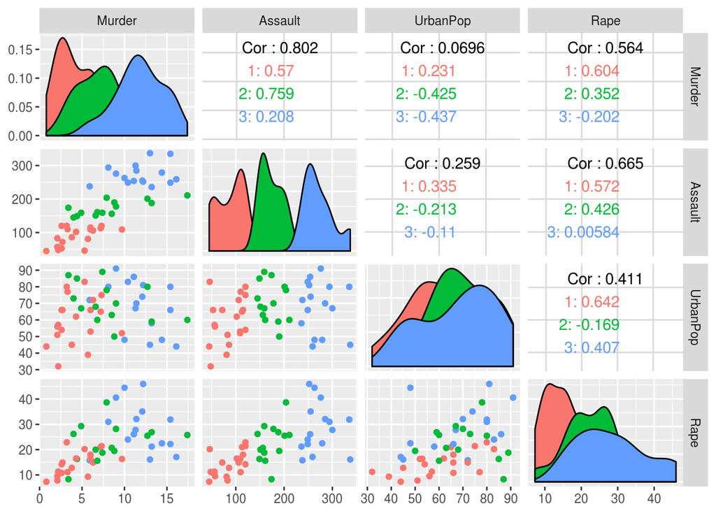

```r
Arrests$clusters = factor(km.out$cluster)
ggpairs(Arrests, mapping = ggplot2::aes(color = clusters), columns = c("Murder", "Assault", "UrbanPop", "Rape"))
```

Если вы обратите внимание, то лучше всего кластеры разбились по *Assault*. А почему так произошло?

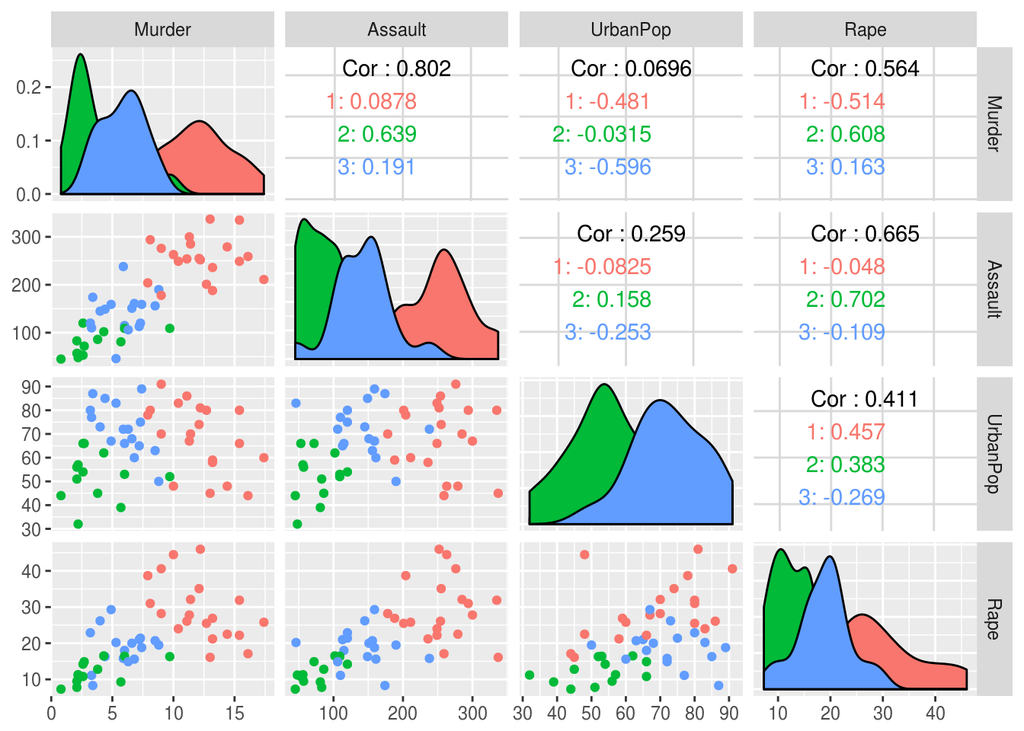

```r
scaledArrests <- scale(Arrests[,1:4])
km.out=kmeans(scaledArrests,3,nstart=1)
Arrests$clusters = factor(km.out$cluster)
ggpairs(Arrests, mapping = ggplot2::aes(color = clusters), columns = c("Murder", "Assault", "UrbanPop", "Rape"))
```

Как мы видим, после нормализации данных кластеры довольно сильно изменились.

Это вполне понятно, так как расстояние между объектами вычисляется обычно по формуле $\sqrt{\sum_i (x_i-y_i)^2}$ и если координаты не отмасштабированны, то самая “растянутая” шкала будет важнее всего.

А давайте еще посмотрим, как наши класеры будут выглядеть на графике с главными компонентами в качестве осей.

```r
library(caret)
```

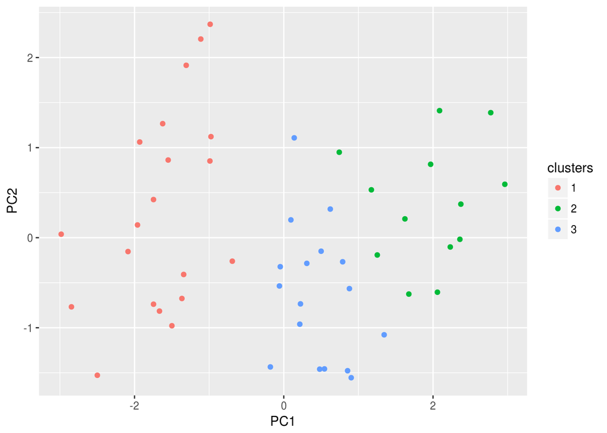

```r
preprocessParams <- preProcess(Arrests, method=c("center", "scale", "pca"))
pcaArrests<-predict(preprocessParams, Arrests)
ggplot()+geom_point(data=pcaArrests, aes(x=PC1, y=PC2,color=clusters))
```

Мы видим, что на главных компонентах разделение выглядит очень понятным.

У k-means есть несколько недостатков:

1. Полученное распределение может быть локальным минимум квадратов расстояний до центра.
2. Результат зависит от выбора исходных центров кластеров.
3. Число кластеров надо знать заранее.

Пример, когда мы получаем два разных разбиения:

```r
set.seed(100)
km.out=kmeans(scaledArrests,3,nstart=1)
clusters1 = km.out$cluster
km.out=kmeans(scaledArrests,3,nstart=1)
clusters2 = km.out$cluster
table(clusters1,clusters2)
```

```
##          clusters2
## clusters1  1  2  3
##         1  0 16  1
##         2 13  0  7
##         3  0 13  0
```

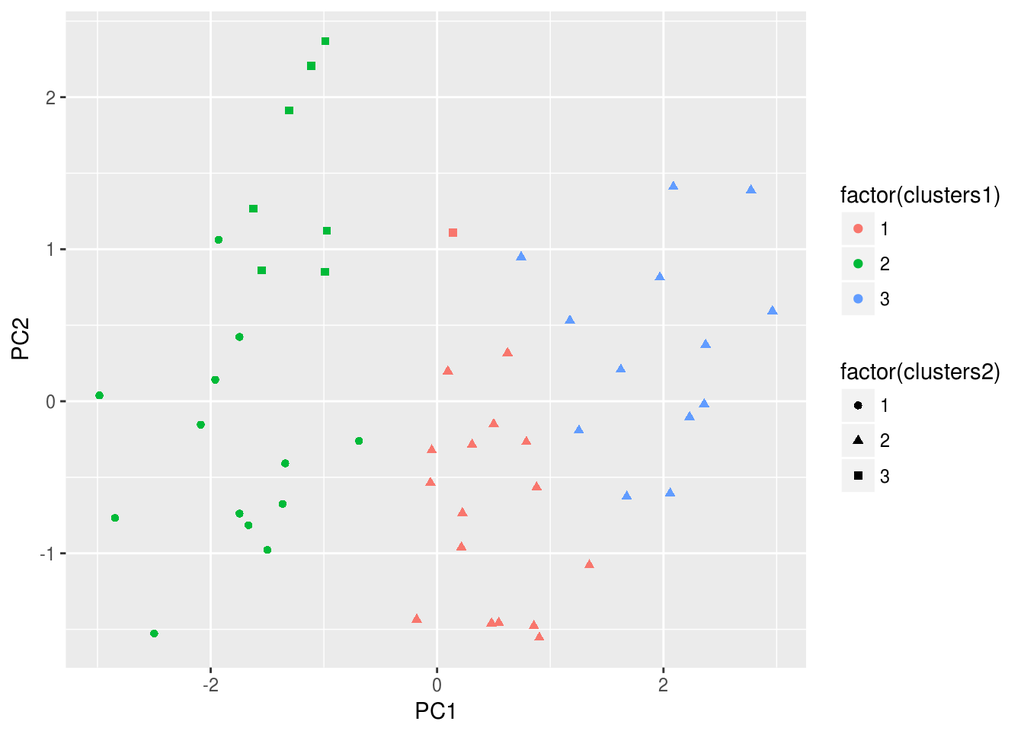

```r
ggplot()+geom_point(data=pcaArrests, aes(x=PC1, y=PC2,color=factor(clusters1), shape=factor(clusters2)))
```

### Иерархическая кластеризация

Как мы уже сказали, один из недостатков метода *k-means* – это необходимость знать число кластеров, плюс некоторая случайность. Давайте посмотрим на метод, который не требует знать число кластеров.

Как мы вам расказывали на лекции, иерахическая кластеризация может строится или на объединении кластеров (агломеративная) или на разбиении. Мы будем работать с первым случаем.

Для того, чтобы выбрать какие кластеры объединять на очередном шаге, мы должны уметь вычислять расстояние не только между точками, но и между кластерами.

Существует много таких способов! Самые простые способы определить расстояние между кластерами:

1. Complete Linkage: Расстояние равно самому *большому* расстоянию между точкой одного кластера и точкой другого.
2. Single Linkage: Расстояние равно самому *маленькому* расстоянию между точкой одного кластера и точкой другого.
3. Average Linkage: Расстояние равно *среднему* расстоянию между точками одного кластера и точками другого.
4. Centroid: Расстояние равно расстоянию между центрами кластеров.

Сравним первые три варианта:

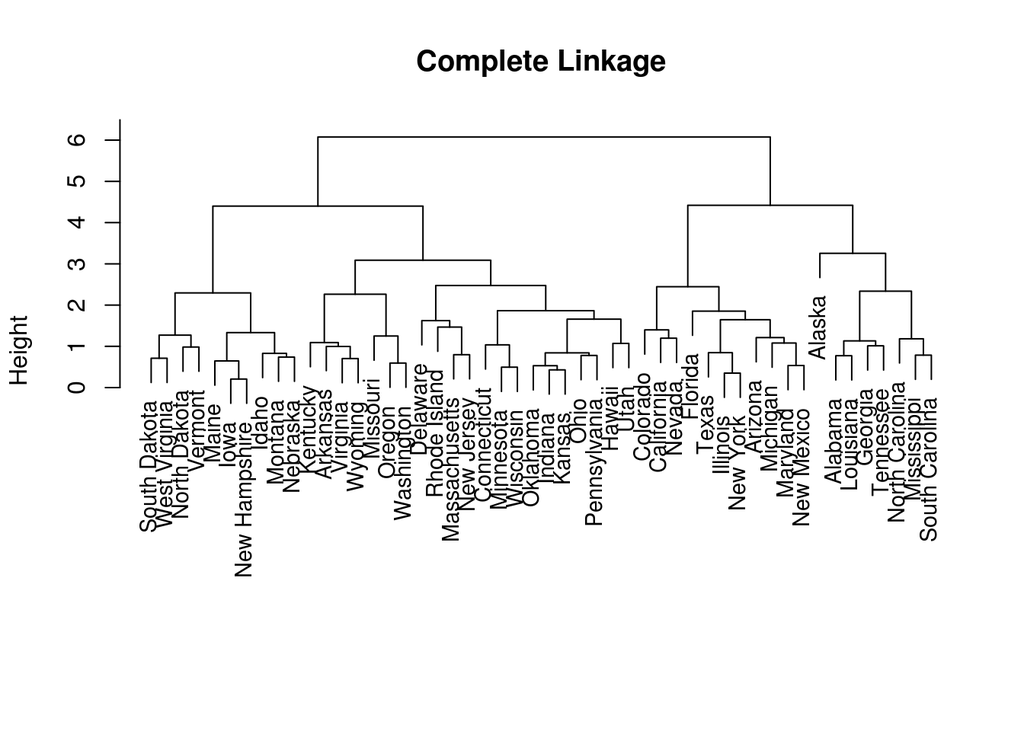

```r
hc.complete=hclust(dist(scaledArrests), method="complete")
hc.average=hclust(dist(scaledArrests), method="average")
hc.single=hclust(dist(scaledArrests), method="single")
#par(mfrow=c(1,3))
plot(hc.complete,main="Complete Linkage", xlab="", sub="", cex=.9)
```

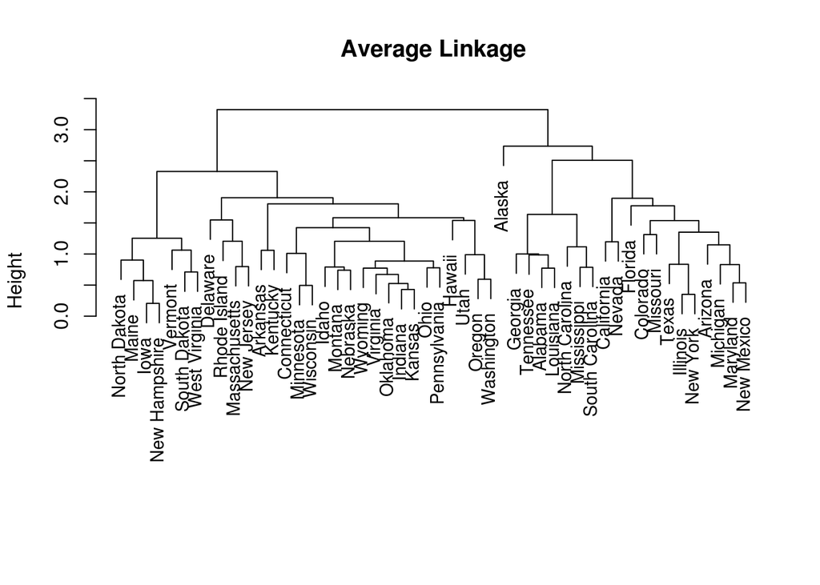

```r
plot(hc.average, main="Average Linkage", xlab="", sub="", cex=.9)
```

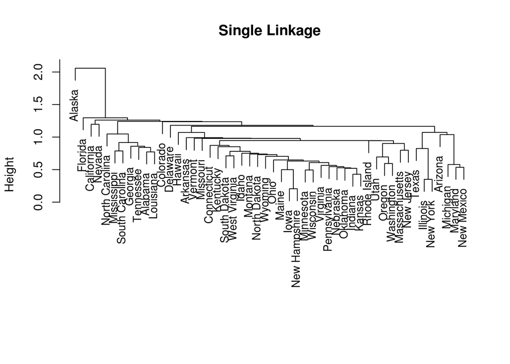

```r
plot(hc.single, main="Single Linkage", xlab="", sub="", cex=.9)
```

Как вы видите, мы получили три разных дендрограммы. Какая из них лучше – зависит от вашей задачи.

Но обычно нам не нужны все кластеры. Имея дендрограммы, мы легко можем получить разбиение на заданное число кластеров, например на 3.

```r
hclusters = cutree(hc.complete, 3)
```

Сравним с k-means

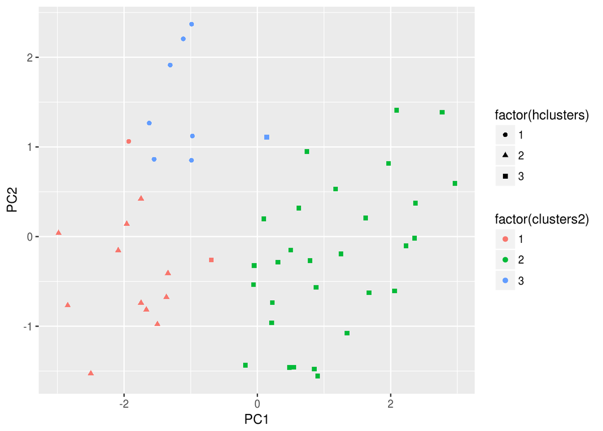

```r
ggplot()+geom_point(data=pcaArrests, aes(x=PC1, y=PC2,color=factor(clusters2), shape=factor(hclusters)))
```

Есть еще одна функция, которая может быть полезна, – *heatmap*. Она рисует матрицу данных цветами и добавляет дендрограммы аналогичные иерархической кластеризации.

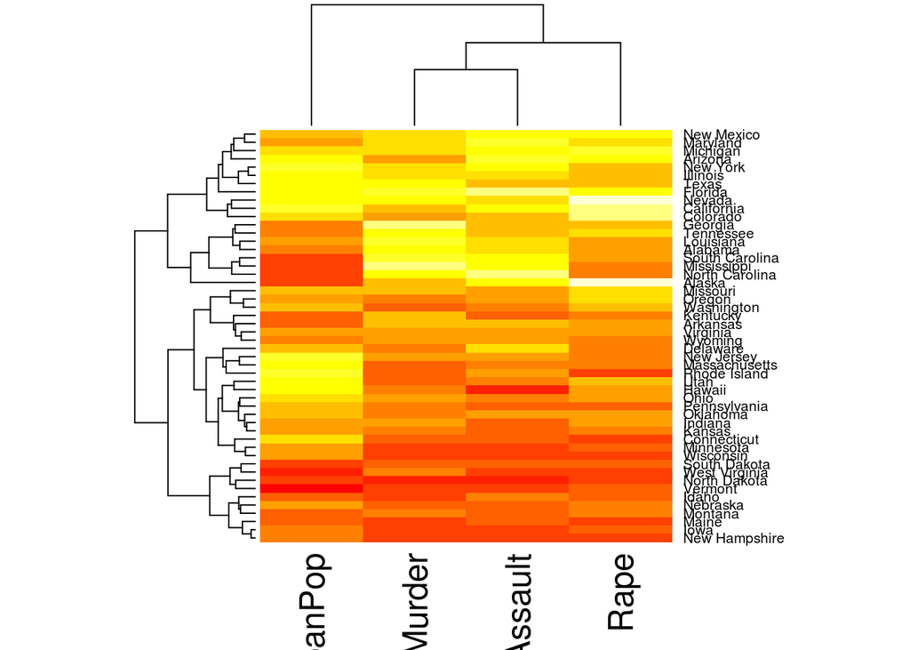

```r
heatmap(as.matrix(scaledArrests),hclustfun = function(x) hclust(x,method = "complete"), scale="none")
```

А вот пример с информацией о генах.

Загрузим данные.

```r
library(ISLR)
#?NCI60
nci.labs=NCI60$labs
nci.data=NCI60$data
dim(nci.data)
```

```
## [1]   64 6830
```

```r
nci.labs[1:4]
```

```
## [1] "CNS"   "CNS"   "CNS"   "RENAL"
```

```r
table(nci.labs)
```

```
## nci.labs
##      BREAST         CNS       COLON K562A-repro K562B-repro    LEUKEMIA
##           7           5           7           1           1           6
## MCF7A-repro MCF7D-repro    MELANOMA       NSCLC     OVARIAN    PROSTATE
##           1           1           8           9           6           2
##       RENAL     UNKNOWN
##           9           1
```

*Иерархическая кластеризация*

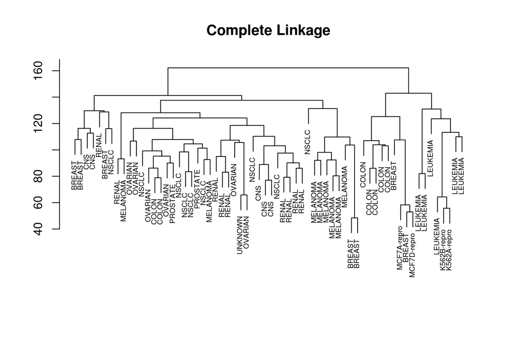

```r
# Clustering the Observations of the NCI60 Data

sd.data=scale(nci.data)
#par(mfrow=c(1,3))
data.dist=dist(sd.data)
plot(hclust(data.dist), labels=nci.labs, main="Complete Linkage", xlab="", sub="",ylab="", cex = 0.6)
```

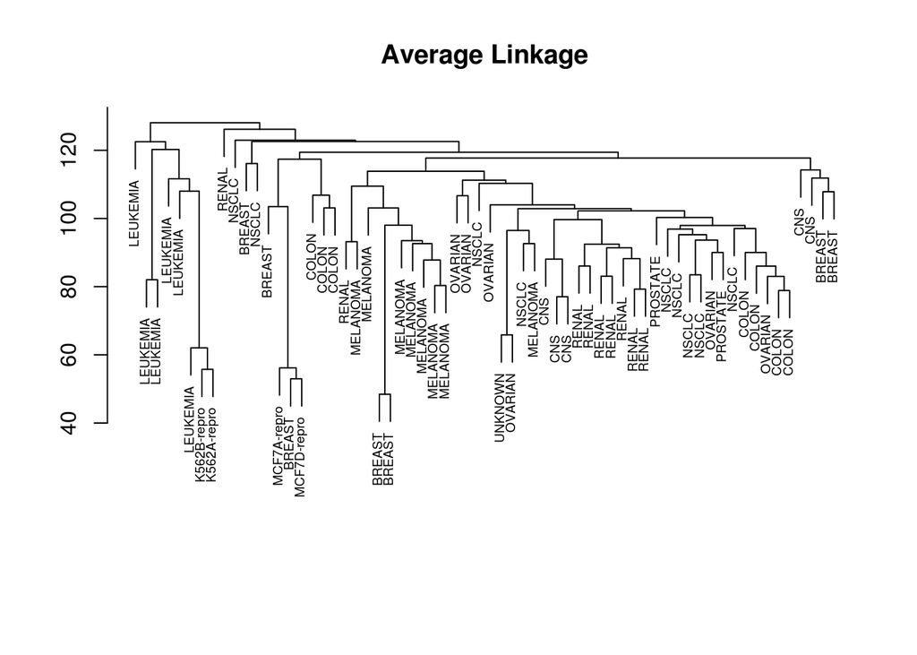

```r
plot(hclust(data.dist, method="average"), labels=nci.labs, main="Average Linkage", xlab="", sub="",ylab="", cex = 0.6)
```

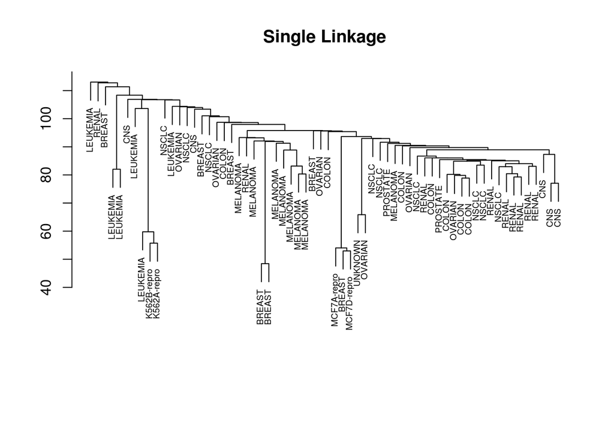

```r
plot(hclust(data.dist, method="single"), labels=nci.labs,  main="Single Linkage", xlab="", sub="",ylab="", cex = 0.6)
```

```r
hc.out=hclust(dist(sd.data))
hc.clusters=cutree(hc.out,4)
table(hc.clusters,nci.labs)
```

```
##            nci.labs
## hc.clusters BREAST CNS COLON K562A-repro K562B-repro LEUKEMIA MCF7A-repro
##           1      2   3     2           0           0        0           0
##           2      3   2     0           0           0        0           0
##           3      0   0     0           1           1        6           0
##           4      2   0     5           0           0        0           1
##            nci.labs
## hc.clusters MCF7D-repro MELANOMA NSCLC OVARIAN PROSTATE RENAL UNKNOWN
##           1           0        8     8       6        2     8       1
##           2           0        0     1       0        0     1       0
##           3           0        0     0       0        0     0       0
##           4           1        0     0       0        0     0       0
```

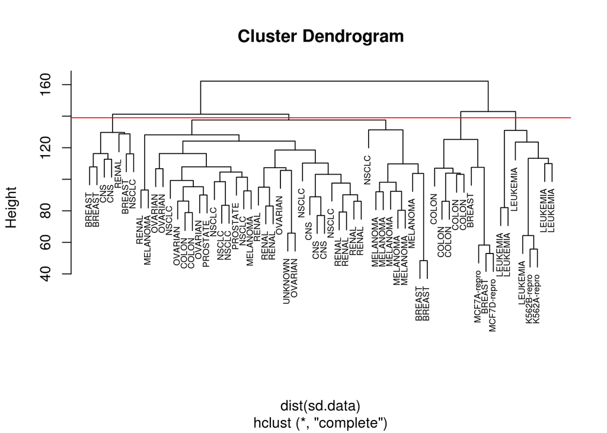

```r
par(mfrow=c(1,1))
plot(hc.out, labels=nci.labs, cex = 0.6)
abline(h=139, col="red")
```

```r
hc.out
```

```
##
## Call:
## hclust(d = dist(sd.data))
##
## Cluster method   : complete
## Distance         : euclidean
## Number of objects: 64
```

*k-means*

```r
set.seed(2)
km.out=kmeans(sd.data, 4, nstart=20)
km.clusters=km.out$cluster
table(km.clusters,hc.clusters)
```

```
##            hc.clusters
## km.clusters  1  2  3  4
##           1 11  0  0  9
##           2  0  0  8  0
##           3  9  0  0  0
##           4 20  7  0  0
```

**Теперь ваша очередь**

Сначала маленький классический пример

1. Загрузите датасет Iris
2. Постройте 3 кластера с помошью k-means.
3. Постройте 3 кластера с помошью иерархической кластеризации.
4. Сравните результаты с настоящими значениями сортов.

```r
iris
```

```
##     Sepal.Length Sepal.Width Petal.Length Petal.Width    Species
## 1            5.1         3.5          1.4         0.2     setosa
## 2            4.9         3.0          1.4         0.2     setosa
## 3            4.7         3.2          1.3         0.2     setosa
## 4            4.6         3.1          1.5         0.2     setosa
## 5            5.0         3.6          1.4         0.2     setosa
## 6            5.4         3.9          1.7         0.4     setosa
## 7            4.6         3.4          1.4         0.3     setosa
## 8            5.0         3.4          1.5         0.2     setosa
## 9            4.4         2.9          1.4         0.2     setosa
## 10           4.9         3.1          1.5         0.1     setosa
## 11           5.4         3.7          1.5         0.2     setosa
## 12           4.8         3.4          1.6         0.2     setosa
## 13           4.8         3.0          1.4         0.1     setosa
## 14           4.3         3.0          1.1         0.1     setosa
```

[output cut: 136 more lines]

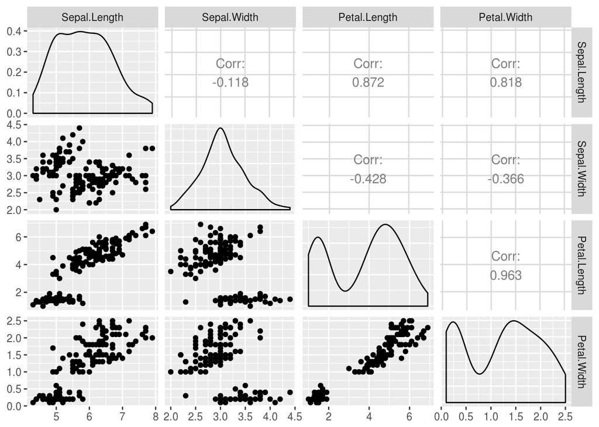

```r
library(ggplot2)
library(GGally)
ggpairs(iris[,1:4])
```

```r
summary(iris)
```

```
##   Sepal.Length    Sepal.Width     Petal.Length    Petal.Width
##  Min.   :4.300   Min.   :2.000   Min.   :1.000   Min.   :0.100
##  1st Qu.:5.100   1st Qu.:2.800   1st Qu.:1.600   1st Qu.:0.300
##  Median :5.800   Median :3.000   Median :4.350   Median :1.300
##  Mean   :5.843   Mean   :3.057   Mean   :3.758   Mean   :1.199
##  3rd Qu.:6.400   3rd Qu.:3.300   3rd Qu.:5.100   3rd Qu.:1.800
##  Max.   :7.900   Max.   :4.400   Max.   :6.900   Max.   :2.500
##        Species
##  setosa    :50
##  versicolor:50
##  virginica :50
##
##
##
```

Если вы все сделали, то загрузите датасет с оценками музыкальных групп и посмотрите, что вы можете сделать с ним.

```r
music<-read.csv("music.txt")
```